# ESPO-G6

## Summary Description

ESPO-G6, the “Ensemble de Simulations Post-traitées d’Ouranos - modèles Globaux CMIP6” is an ensemble of bias-adjusted climate simulations created by Ouranos based on the global climate models (GCMs) from CMIP6. It downscales 3 variables for 26 global climate models over a historical period (1950–2014) and three future pathways (SSP2-4.5, SSP3-7.0, SSP5-8.5) using the Detrended Quantile Mapping (DQM) bias-adjustment method. A detailed description of the method is available in Lavoie *et al.* (2024). There are two versions of the of ESPO based on two reference datasets: ESPO-G6-R2 (RDRS/CaSR v2.1) and ESPO-G6-E5L (ERA5-Land). ESPO-G6-R2 is recommended by Ouranos in most cases and serves as the database for [Ouranos Climate Portraits](https://portraits.ouranos.ca/). A detailed description of the dataset is available in Lavoie *et al.* (2024).

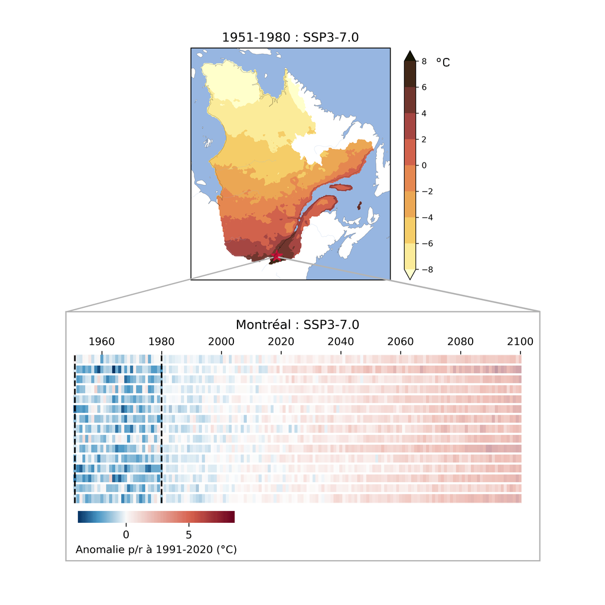

An animated illustration of 30 year temperature anomalies calulated from ESPO-G6 for Quebec and Montreal compared to the 1991-2020 reference period (source: [Ouranos](https://www.ouranos.ca/en/ouranos-climate-data/espo-g6-r2))

## Dataset Characteristics

- **Current version:** 1.0.0
- **Available variables:** temperature & precipitation (see variables section below)
- **Temporal coverage**: 1950-2100
- **Temporal resolution:** daily, noleap or 360_day calendar
- **Spatial coverage:** North American domain from 179.9°W to 10.0°W and from 10.0°N to 83.3°N, only on land.
- **Spatial resolution:** 0.1°
- **Data type:** Bias-adjusted climate projections
- **Data format:** netCDF
- **Web references:**  
  [Ouranos’ Ensemble of Bias-adjusted Simulations - Global models CMIP6 - CaSR v2.1](https://www.ouranos.ca/en/ouranos-climate-data/espo-g6-r2)
- **Reference:**  
  Lavoie *et al.* (2024)
- **Contact:** Ouranos Helpdesk

## When to use ESPO-G6

- When you need **CMIP-based, bias-adjusted future climate projections** for North America
- When you need **downscaled climate data** suitable for **impact studies requiring higher spatial resolution** than CMIP6 and that **better represent local processes** (e.g., topography, coastlines) than global models
- When you need climate projections under **different emissions pathways (SSPs)**
- When you need **scenario-based projections** with improved agreement with the historical baseline of a reanalysis dataset (CaSR or ERA5-Land)
- When you need **inputs for impact models** that are sensitive to biases (e.g., hydrology, energy system, etc.)
- When you want to assess **threshold-based metrics** (e.g., degree days, exceedances, return levels)
- When you want to avoid performing **bias correction and post-processinng workflows** on CMIP6 data

## Strengths and Limitations

### Key Strengths of ESPO-G6

| Strength | Description |
| --- | --- |
| **Accessibility** | Climate projections from this dataset can easily be explored through the online platform [Portraits Climatiques](https://portraits.ouranos.ca/), and many relevant indicators are already computed. |
| **Multi-Model Ensemble** | One member of each available GCM was adjusted to give all models equal representation. |
| **Multiple emission scenarios**. | The ensemble includes simulations driven by three different emission scenarios, which allows it to span a wide range of possible futures. |

### Key Limitations of ESPO-G6

| Limitation | Description |
| --- | --- |
| **Biases remain** | The DQM method does not specifically adjust for sequences, extremes and spatial patterns. |
| **Limited variables** | Focuses primarily on temperature and precipitation; other climate variables are not included. |

## Expert Guidance

**None(click to expand)**

CMIP6 raw simulations have been bias-adjusted (or statistically downscaled) to create ESPO-G6. Technically, this process should make the data more suited to be used in a decision-making context, as the resolution is increased and most biases have been removed. The goal is to use the climate of the reference with the climate change signal of the GCM. A good application for the dataset would be to calculate climatologies of climate indicators (ex. number of days above 30 degC, total accumulated precipitation), rather than values on individual days. If possible, it is ideal to look at the deltas of climatologies (difference between the present and future).

### Choosing the models

Every CMIP6 GCM that was available on ESGF for the variable and scenarios of interest were bias-adjusted. However, in general, we do not recommend that all of them should be used if the timing of the warming is important for the application. Indeed, many CMIP6 models have a climate sensitivity that is much too high (Hausfather *et al.* (2022)). In order to avoid this “hot model problem”, only models with a Transient Climate Response (TCR) in the likely range (1.4–2.2 °C) should be used (Table 1).

**Table 1. Members of ESPO-G6**

| **Institution** | **Model** | **Member** | **TCR (degC)** | **In TCR likely range** |
| --- | --- | --- | --- | --- |
| CAS | FGOALS-g3 | r1i1p1f1 | 1.50 | ✓ |
| CMCC | CMCC-ESM2 | r1i1p1f1 | 1.92 | ✓ |
| CSIRO-ARCCSS | ACCESS-CM2 | r1i1p1f1 | 1.96 | ✓ |
| CSIRO | ACCESS-ESM1-5 | r1i1p1f1 | 1.97 | ✓ |
| DKRZ | MPI-ESM1-2-HR | r1i1p1f1 | 1,64 | ✓ |
| INM | INM-CM5-0 | r1i1p1f1 | 1.41 | ✓ |
| MIROC | MIROC6 | r1i1p1f1 | 1.55 | ✓ |
| MPI-M | MPI-ESM1-2-LR | r1i1p1f1 | 1.82 | ✓ |
| MRI | MRI-ESM2-0 | r1i1p1f1 | 1.67 | ✓ |
| NCC | NorESM2-LM | r1i1p1f1 | 1.49 | ✓ |
| CNRM-CERFACS | CNRM-ESM2-1 | r1i1p1f2 | 1.83 | ✓ |
| NIMS-KMA | KACE-1-0-G | r1i1p1f1 | 2.04 | ✓ |
| NOAA-GFDL | GFDL-ESM4 | r1i1p1f1 | 1.63 | ✓ |
| BCC | BCC-CSM2-MR | r1i1p1f1 | 1.55 | ✓ |
| MIROC | MIROC-ES2L | r1i1p1f2 | 1.49 | ✓ |
| CCCma | CanESM5 | r1i1p1f1 | 2.71 |  |
| CNRM-CERFACS | CNRM-CM6-1 | r1i1p1f2 | 2.22 |  |
| EC-Earth-Consortium | EC-Earth3 | r1i1p1f1 | 2.30 |  |
| IPSL | IPSL-CM6A-LR | r1i1p1f1 | 2.35 |  |
| MOHC | UKESM1-0-LL | r1i1p1f2 | 2.77 |  |
| NCC | NorESM2-MM | r1i1p1f1 | 1.22 |  |
| EC-Earth-Consortium | EC-Earth3-CC | r1i1p1f1 | 2.63 |  |
| NUIST | NESM3 | r1i1p1f1 | 2.72 |  |
| EC-Earth-Consortium | EC-Earth3-Veg | r1i1p1f1 | 2.66 |  |
| INM | INM-CM4-8 | r1i1p1f1 | 1.30 |  |
| AS-RCEC | TaiESM1 | r1i1p1f1 | 1.30 |  |

### Choosing the scenario

“Ouranos suggests adopting a risk analysis perspective, and interpreting SSP2-4.5 as the median scenario and SSP3-7.0 as the upper scenario. According to Working Group III of the latest IPCC report, SSP5-8.5 (like RCP8.5) does not represent a typical business-as-usual scenario and is currently considered unlikely. It is useful only as a high-risk scenario, representative of the upper limit of “no climate policy” scenarios. SSP5-8.5 may be relevant in the context of unlikely hazards with catastrophic consequences, or as an analogue for a post-2100 climate, useful for land-use planning, for example.” (Source: Portrait Climatiques (2025) )

### Choosing the reference

There are two sub-ensembles of ESPO-G6 based on two reference datasets: ESPO-G6-R2 (RDRS/CaSR v2.1) and ESPO-G6-E5L (ERA5-Land). Officially, Ouranos recommends ESPO-G6-R2. However, users with specific regions can consult the CaSR and ERA5-Land pages to see if a dataset is better suited to their region. If a user has the capacity to handle a large ensemble and wants to cover the full range of uncertainty, they could also use both sub-ensemble.

### Problematic Areas

- Users should be careful with precipitation data close to the south edge of the North American domain where there is less trust in the reference data.
- Some small regions in Alaska and Greenland showed very small tasmin and have been masked out by NaNs for 2 models (BCC-CSM2-MR and GFDL-ESM4 ). More details are available in section Health Checks of Lavoie *et al.* (2024).

### Validation

A validation using the VALUE framework is presented in Lavoie *et al.* (2024).

## Variables available in ESPO-G6

*For details click on variable group to uncollapse*

**NoneTemperature**

- Daily maximum temperature [K]
- Daily minimum temperature [K]  
  (Calculated from adjusted tasmax and adjusted? daily temperature range)

**NonePrecipitation**

- Mean daily precipitation flux [kg m<sup>-2</sup> s<sup>-1</sup>] (equal to [mm s<sup>-1</sup>])

**NoneOther variables**

Many climate indicators based on minimum temperature, maximum temperature and precipitation have been pre-calculated from the ESPO-G6 dataset. See the download section for details.

## Data Access

The ESPO-G6 dataset’s bias adjusted climate variables and all indicators calculated from it are available on [PAVICS](https://pavics.ouranos.ca/datasets.html#a) for the North American continent. For the province of Quebec, indicators can be browsed on [Ouranos’ Climate Portraits](https://portraits.ouranos.ca).

To avoid downloading very large datasets in their entirety PAVICS allows partial/regional extraction and provides [tutorials](https://pavics.ouranos.ca/climate_analysis.html#a) to do so. With a free PAVICS user account, the Jupyter notebook with the Python code from the tutorials can be [directly used on PAVICS](https://pavics.ouranos.ca/jupyter/hub/user-redirect/lab/tree/pavics-homepage/PAVICStutorial_ClimateDataAnalysis-1DataAccess.ipynb). The Python code used in the generation of ESPO-G6 is available in this [GitHub repository](https://github.com/Ouranosinc/ESPO-G).

## References

Hausfather, Z., Marvel, K., Schmidt, G. A., Nielsen-Gammon, J. W., & Zelinka, M. (2022). [Climate simulations: Recognize the ’hot model’ problem](https://doi.org/10.1038/d41586-022-01192-2). *Nature*, **605**(7908), 26–29.

Lanzante, J. R., Dixon, K. W., & Adams-Smith, D. (2025). [Variance distortion via indirect downscaling of daily minimum temperature from diurnal temperature range](https://doi.org/10.1175/JAMC-D-25-0009.1). *Journal of Applied Meteorology and Climatology*, **64**(9), 1093–1104.

Lavoie, J., Bourgault, P., Logan, T., … Braun, M. (2023, April). ESPO-G6-R2 : Ensemble de simulations post-traitées d’ouranos - modèles globaux CMIP6 - RDRS v2.1 / ouranos ensemble of bias-adjusted simulations - global models CMIP6 - RDRS v2.1 (Version ESPO-G6-R2v1.0.0), Zenodo. doi:10.5281/zenodo.7877330

Lavoie, J., Bourgault, P., Smith, T. J., … Braun, M. (2024). [An ensemble of bias-adjusted CMIP6 climate simulations based on a high-resolution north american reanalysis](https://doi.org/10.1038/s41597-023-02855-z). *Scientific Data*, **11**(1), 64.